# Electricity demand modelling on GEFCom14 data: solution

1. Load data and fit a basic Gaussian GAM:

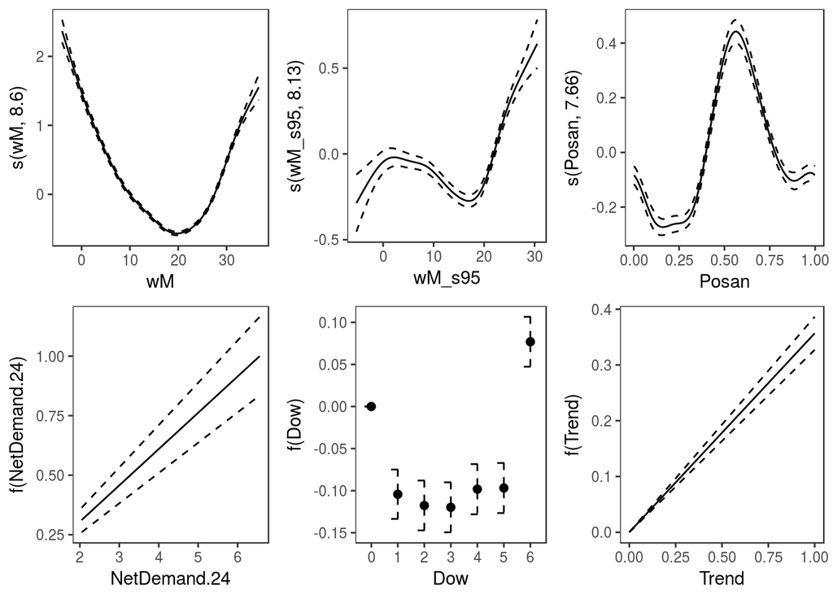

```r
library(mgcViz)
load(paste0(goodLocation, "/data/gefcom_small.rda")) # change this

fit1 <- gamV(NetDemand ~ NetDemand.24 + Dow + Trend + s(wM) + s(wM_s95) + s(Posan, bs = "cc"),
             data = gefcom_small, aViz = list(nsim = 50))

print(plot(fit1, allTerms = TRUE), pages = 1)
```

2. We check the mean residuals as a function of time (`trend`):

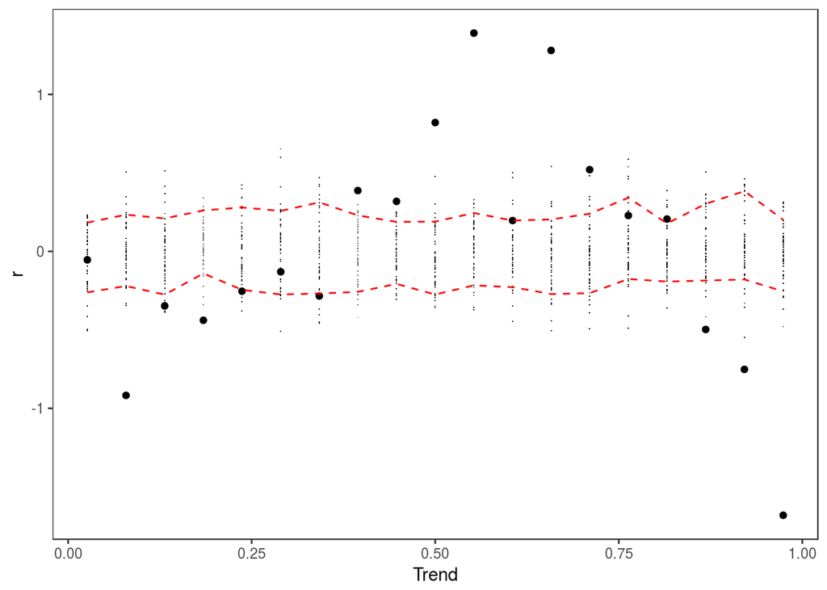

```r
check1D(fit1, "Trend") + l_gridCheck1D()
```

The long term trend seems to be non-linear. We also check whether we should increase the bases dimension:

```r
check(fit1)
```

```
##
## Method: REML   Optimizer: outer newton
## full convergence after 7 iterations.
## Gradient range [-0.0002690126,0.000237972]
## (score -397.9388 & scale 0.04001808).
## Hessian positive definite, eigenvalue range [3.287508,1255.534].
## Model rank =  35 / 35
##
## Basis dimension (k) checking results. Low p-value (k-index<1) may
## indicate that k is too low, especially if edf is close to k'.
##
##             k'  edf k-index p-value
## s(wM)     9.00 8.60    0.91  <2e-16 ***
## s(wM_s95) 9.00 8.13    1.02    0.74
## s(Posan)  8.00 7.66    1.04    0.98
## ---
## Signif. codes:  0 '***' 0.001 '**' 0.01 '*' 0.05 '.' 0.1 ' ' 1
```

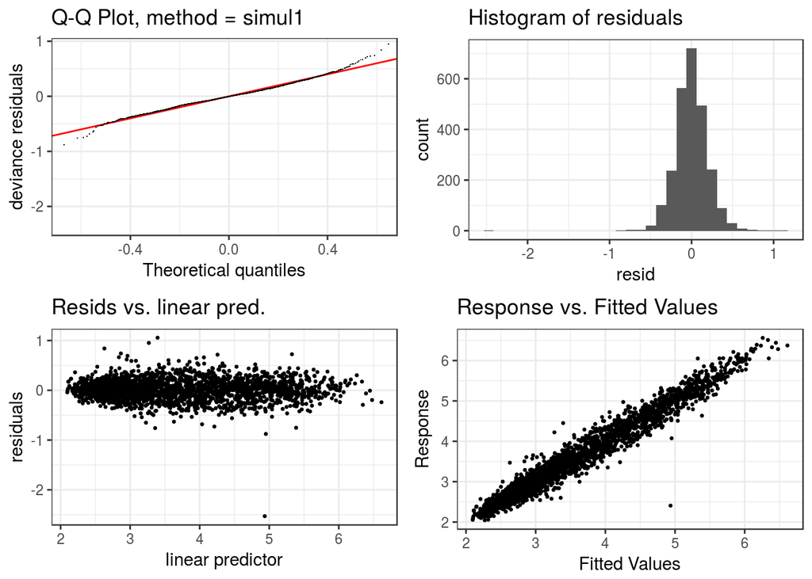

`edf` is quite close to `k'` for all effects, and we get a very low p-value for `wM`. We have to increase `k` a bit.

3. Re-fit with a smooth long-term trend and increase basis dimension:

```r
fit2 <- gamV(NetDemand ~ NetDemand.24 + Dow + s(Trend, k = 6) + s(wM, k = 20) +
             s(wM_s95, k = 15) + s(Posan, k = 15, bs = "cc"), data = gefcom_small,
             aViz = list(nsim = 50))

AIC(fit1, fit2)
```

```
##            df        AIC
## fit1 34.71536  -923.9217
## fit2 50.00507 -1187.4480
```

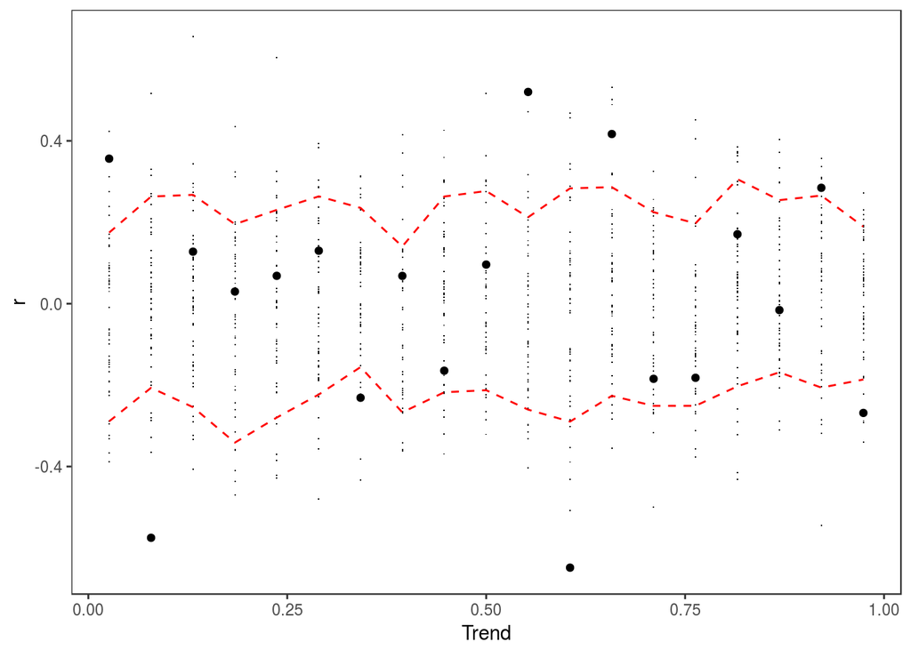

```r
check1D(fit2, "Trend") + l_gridCheck1D()
```

AIC is much inproved, and there is no systematic residual pattern along `trend`. We recheck using `check`:

```r
check(fit2)
```

```
##
## Method: REML   Optimizer: outer newton
## full convergence after 7 iterations.
## Gradient range [-4.001715e-06,2.372158e-06]
## (score -517.8392 & scale 0.03582405).
## Hessian positive definite, eigenvalue range [1.824204,1255.579].
## Model rank =  59 / 59
##
## Basis dimension (k) checking results. Low p-value (k-index<1) may
## indicate that k is too low, especially if edf is close to k'.
##
##              k'   edf k-index p-value
## s(Trend)   5.00  4.58    0.78  <2e-16 ***
## s(wM)     19.00 13.81    0.96    0.01 **
## s(wM_s95) 14.00 10.14    1.02    0.87
## s(Posan)  13.00 11.51    1.00    0.60
## ---
## Signif. codes:  0 '***' 0.001 '**' 0.01 '*' 0.05 '.' 0.1 ' ' 1
```

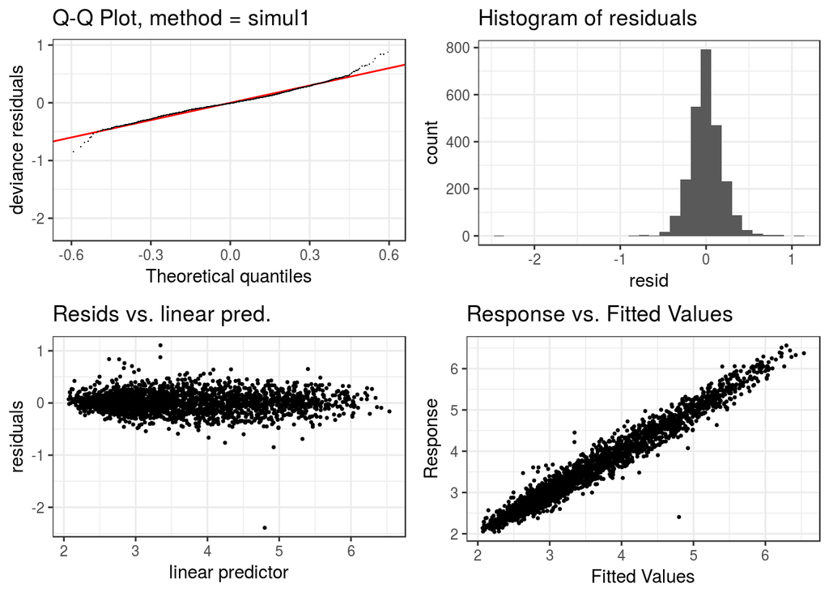

Maybe we should increase the basis dimension for `wM` a bit more. But increasing the basis dimension for `Trend` too much is definitely not a good idea, because we would end up interpolating the data.

4. Look at a qq-plot:

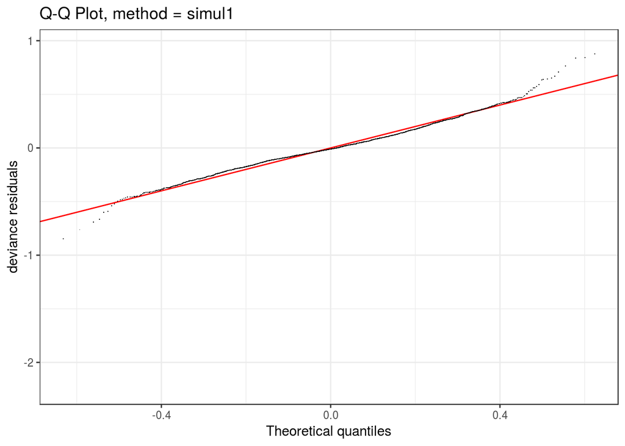

```r
qq(fit2)
```

We have some fairly fat tails, maybe better to adopt a scaled student-t distribution:

```r
fit3 <- gamV(NetDemand ~ NetDemand.24 + Dow + s(Trend, k = 6) + s(wM, k = 20) +
             s(wM_s95, k = 15) + s(Posan, k = 15, bs = "cc"), data = gefcom_small,
             family = scat,
             aViz = list(nsim = 50))

AIC(fit2, fit3)
```

```
##            df       AIC
## fit2 50.00507 -1187.448
## fit3 52.62690 -1469.648
```

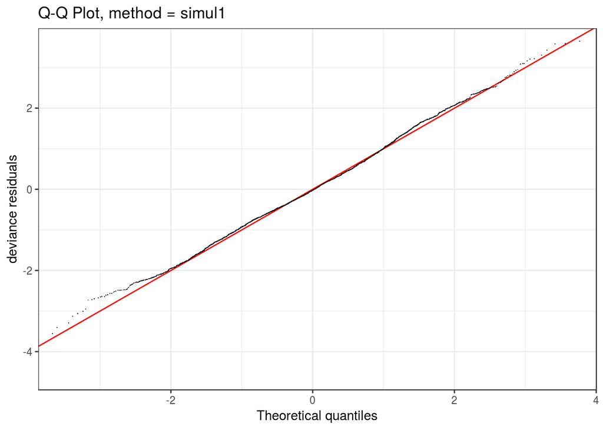

```r
qq(fit3)
```

Better AIC, and the QQ-plot looks much better.

5. Worth considering the log-link, as an alternative to the identity link:

```r
fit4 <- gamV(NetDemand ~ NetDemand.24 + Dow + s(Trend, k = 6) + s(wM, k = 20) +
             s(wM_s95, k = 15) + s(Posan, k = 15, bs = "cc"),
             data = gefcom_small,
             family = scat(link = log),
             aViz = list(nsim = 50))

AIC(fit3, fit4)
```

```
##            df       AIC
## fit3 52.62690 -1469.648
## fit4 53.19137 -1490.144
```

Seems better in terms of AIC. We finally plot the fitted effects:

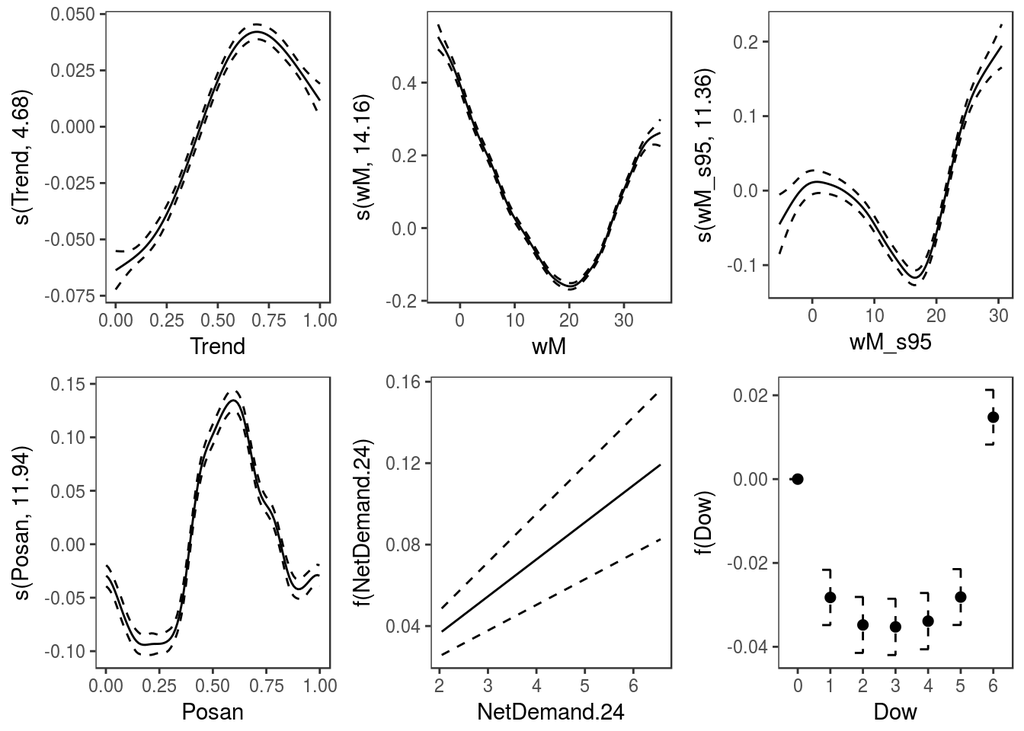

```r
print(plot(fit4, allTerms = TRUE), pages = 1)
```